# Peer Graded Assignment: Course Project 1

## Peer Graded Assignment: Course Project 1

## *July 5, 2016*

## Introduction

It is now possible to collect a large amount of data about personal movement using activity monitoring devices such as a Fitbit, [Nike Fuelband](http://www.nike.com/us/en_us/c/nikeplus-fuelband), or [Jawbone Up](https://jawbone.com/up). These type of devices are part of the “quantified self” movement – a group of enthusiasts who take measurements about themselves regularly to improve their health, to find patterns in their behavior, or because they are tech geeks. But these data remain under-utilized both because the raw data are hard to obtain and there is a lack of statistical methods and software for processing and interpreting the data.

This assignment makes use of data from a personal activity monitoring device. This device collects data at 5 minute intervals through out the day. The data consists of two months of data from an anonymous individual collected during the months of October and November, 2012 and include the number of steps taken in 5 minute intervals each day.

## Loading and preprocessing the data

### Load neccesary libraries

```r
library(dplyr)
library(lattice)
library(ggplot2)
library(plotrix)
```

### Download the data

```r
fileurl <- "https://d396qusza40orc.cloudfront.net/repdata%2Fdata%2Factivity.zip"
f <- file.path(getwd(),  "activity.zip")
download.file(fileurl, f, method = "curl")
```

### Unzip the data

```r
unzip(zipfile = f, exdir = ".")

## Path to the dataset
path <- file.path(getwd())
```

### Read the dataset

```r
a <- tbl_df(read.csv(file.path(path, "activity.csv")))
```

### Take a peek at data

```r
str(a)
```

```
## Classes 'tbl_df', 'tbl' and 'data.frame':    17568 obs. of  3 variables:
##  $ steps   : int  NA NA NA NA NA NA NA NA NA NA ...
##  $ date    : Factor w/ 61 levels "2012-10-01","2012-10-02",..: 1 1 1 1 1 1 1 1 1 1 ...
##  $ interval: int  0 5 10 15 20 25 30 35 40 45 ...
```

## What is mean total number of steps taken per day?

```r
## For this part of the assignment, missing values in the dataset will be ignored.
a1 <- a[complete.cases(a),]

## Take a peek at data with NAs ignored
str(a1)
```

```
## Classes 'tbl_df' and 'data.frame':   15264 obs. of  3 variables:
##  $ steps   : int  0 0 0 0 0 0 0 0 0 0 ...
##  $ date    : Factor w/ 61 levels "2012-10-01","2012-10-02",..: 2 2 2 2 2 2 2 2 2 2 ...
##  $ interval: int  0 5 10 15 20 25 30 35 40 45 ...
```

```r
## Aggregate total number of steps by day
total_steps <- aggregate(a1$steps, by=list(a1$date), FUN = sum)

## Give columns appropriate names
colnames(total_steps) <- c("date", "steps")

## Histogram of the total number of steps taken each day
hist(total_steps$steps, col=4, main = "Histogram of the total number of steps by day",
     xlab = "Total number of steps in a day",
        tck = 0.02, cex.axis = 1.5, cex.lab = 1.4,
            cex.main = 1.5, font.lab = 2)

## The mean and median of the total number of steps taken per day
mean(total_steps$steps)
```

```
## [1] 10766.19
```

```r
median(total_steps$steps)
```

```
## [1] 10765
```

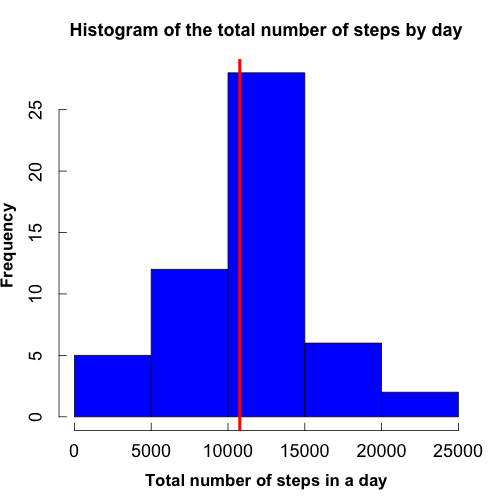

```r
## Vertical red line on histogram showing the position of mean of the total number of
## steps taken per day
abline(v=mean(total_steps$steps), col = "red", lwd = 4)
```

## What is the average daily activity pattern?

```r
## Make a time series plot (i.e. type = "l") of the 5-minute interval
## (x-axis) and the average number of steps taken, averaged across all days (y-axis)

## Aggregate avearge number of steps by 5-minute interval accross all days
steps_ave_interv <-aggregate(a1$steps, by=list(a1$interval ), FUN = mean)

## Give columns appropriate names
colnames(steps_ave_interv) <- c("interval", "steps")

## Time series plot
plot(steps_ave_interv$interval,steps_ave_interv$steps, type = "l", main =
    "Average number of steps, averaged across all days",
            xlab = "Interval", ylab = "Average number of steps", tck = 0.02)

## 5-minute interval, on average across all the days in the dataset, containing
## the maximum number of steps
maxstep <- which.max(steps_ave_interv$steps)

## subset corresponding to the maximum number of steps
steps_ave_interv[maxstep, ]
```

```
##     interval    steps
## 104      835 206.1698
```

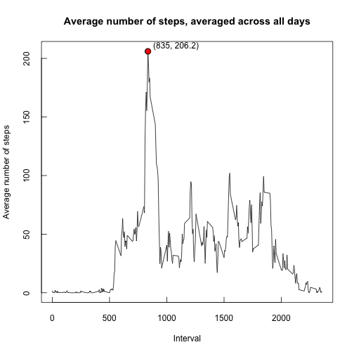

```r
## Legend with the position of maximum number of steps
legend(x=750, y=220, "(835, 206.2)", bty = "n")
draw.circle(835,206,25, col = "red")
```